# Yunqing Zhao – zhao_yunqing_pca_segmentation

Using PCA for Customer Segmentation

How Principal Component Analysis Helps Simplify Marketing Data

Yunqing Zhao  
Marketing Analytics  
Spring 2026

The Problem with Marketing Data

Marketing data is complex, messy, and hard to use.

Before PCA, we often deal with too many variables and noisy data, which makes it difficult to understand customers.

Too Many Variables

Age

Income

Website Visits

Purchase Frequency

Ad Clicks

Spending

Session Time

Product Views

Email Opens

Returns

Location

Loyalty Score

...

...

• Many different metrics.  
• Hard to decide what matters most.

Highly Correlated

• Many variables move together.  
• Redundant information adds noise.

Hard to Visualize

📊 📈

😟

• Too much data to interpret.  
• Hard to see customer patterns.

⚠️

This is where dimension reduction techniques come in:  
PCA is one of the most common techniques used to reduce complexity and redundancy in high-dimensional data.

How PCA Finds New Dimensions

PCA rotates the data to find the most informative directions.

Original Data

[figure not shown]

Variables are correlated.  
Patterns are difficult to interpret in high dimensions.

→

PCA  
Rotation

After PCA

[figure not shown]

✓

PCA does **not** remove data randomly.  
It combines correlated variables into a few new, meaningful components.

PCA for Perceptual Maps

Marketers use PCA to visualize how consumers perceive brands and products.

1. Many Attributes  
(Hard to Visualize)

💵 Price

🏅 Quality

💡 Innovation

🛒 Convenience

💎 Luxury

🌿 Sustainability

...

➡

PCA

2. Perceptual Map  
(Easy to Understand)

▶

▲

PC2  
(Premium Perception)

PC1  
(Value)

●

brand 1

●

brand 2

●

brand 3

●

brand 4

●

brand 5

●

brand 6

⭐

Key Takeaway: Perceptual maps help marketers understand brand positioning, competitive landscape, and customer perception in a simple 2D view.

Using PCA for Customer Segmentation

PCA helps reveal customer segments more clearly.

Before PCA: Many Variables

🛒 Purchase Frequency

💻 Website Visits

🖱️ Ad Clicks

💰 Spending

⏱️ Session Time

⭐ Loyalty Score

… …

→

PCA

After PCA: 2 Key Dimensions

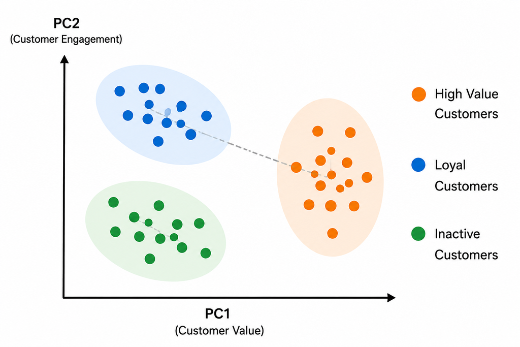

📊

✔ PCA is often used before clustering because many clustering methods rely on distance calculations that become less effective in high dimensions.

✔ It helps marketers visualize customer segments more clearly.

✔ It also improves speed and reduces noise in machine learning models.

Key Takeaways

📊

1

PCA reduces complex marketing data into simpler dimensions.

👥

2

It helps visualize customer behavior and segmentation.

🔗

3

PCA removes redundant information from correlated variables.

⚠️

4

PCA is powerful, but interpretation can sometimes be difficult.

⭐

PCA helps marketers focus on the signal instead of the noise.